# Exercise 6.4: Predicting the Price of Used Toyota Corolla Cars

Emily Schmidt

2022-11-16

**Completed exercise using the Data Mining textbook, not the errata.**

```r
library(data.table) # Fast aggregation of large data sets and a fast file reader
library(lubridate) # Commute date-times
library(cowplot) # A simple add-on to ggplot
library(caret) # Functions that attempt to streamline the process for creating predictive models
library(kableExtra) # Add elements to a a pivot table
library(reshape2) # Easily transform our data into whatever structure we may need
library(fastDummies) # Provides a significant speed increase from creating dummy variables
library(randomizr) # Generates random assignments for common experimental designs and random samples for common sampling designs
library(FNN) # Used for KNN estimation
library(tidyr) # Contains tools for changing the shape and hierarchy of a data set
library(DataExplorer) # Used to graph missing value percentages
library(dbplyr) # Transposed version of print()*
library(forecast) # Use with predict()*
library(leaps) # Use with regsubets()*
```

```r
setwd("C:\\Users\\emann\\GSEM Master\\Data Mining\\Homework 3") # Set directory
getwd() # Check the working directory
```

```
## [1] "C:/Users/emann/GSEM Master/Data Mining/Homework 3"
```

```r
Toyota <- read.csv("ToyotaCorolla.csv", sep = ",", header = T) # Load your data, ToyotaCorolla

options(scipen = 10000) # Avoid scientific notation
```

#### Data Overview

Predicting Prices of Used Cars. The file ToyotaCorolla.csv contains data on used cars (Toyota Corolla) on sale during late summer of 2004 in the Netherlands. It has 1,436 records containing details on 39 attributes, including Price, Age, Kilometers, HP, and other specifications. The goal is to predict the price of a used Toyota Corolla based on its specifications. (The example in Section 6.3 is a subset of this dataset.) Split the data into training (50%), validation (30%), and test (20%) datasets. Run a multiple linear regression with the outcome variable Price and predictor variables Age_08_04, KM, Fuel_Type, HP, Automatic, Doors, Quarterly_Tax, Mfr_Guarantee, Guarantee_Period, Airco, Automatic_airco, CD_Player, Powered_Windows, Sport_Model, and Tow_Bar.

## Data Exploration

```r
dim(Toyota) # Get or set the dimension of the specified matrix, array or data frame
```

```
## [1] 1436   39
```

```r
head(Toyota) # Display the first n rows present in the input data frame
```

```
##   Id                                             Model Price Age_08_04
## 1  1     TOYOTA Corolla 2.0 D4D HATCHB TERRA 2/3-Doors 13500        23
## 2  2     TOYOTA Corolla 2.0 D4D HATCHB TERRA 2/3-Doors 13750        23
## 3  3 \xa0TOYOTA Corolla 2.0 D4D HATCHB TERRA 2/3-Doors 13950        24
## 4  4     TOYOTA Corolla 2.0 D4D HATCHB TERRA 2/3-Doors 14950        26
## 5  5       TOYOTA Corolla 2.0 D4D HATCHB SOL 2/3-Doors 13750        30
## 6  6       TOYOTA Corolla 2.0 D4D HATCHB SOL 2/3-Doors 12950        32
##   Mfg_Month Mfg_Year    KM Fuel_Type HP Met_Color  Color Automatic   CC Doors
## 1        10     2002 46986    Diesel 90         1   Blue         0 2000     3
## 2        10     2002 72937    Diesel 90         1 Silver         0 2000     3
## 3         9     2002 41711    Diesel 90         1   Blue         0 2000     3
## 4         7     2002 48000    Diesel 90         0  Black         0 2000     3
## 5         3     2002 38500    Diesel 90         0  Black         0 2000     3
## 6         1     2002 61000    Diesel 90         0  White         0 2000     3
##   Cylinders Gears Quarterly_Tax Weight Mfr_Guarantee BOVAG_Guarantee
```

[output cut: 34 more lines]

```r
#View(Toyota) # Invoke a spreadsheet-style data viewer within RStudio
summary(Toyota) # Produce result summaries of the results of various model fitting functions
```

```
##        Id            Model               Price         Age_08_04
##  Min.   :   1.0   Length:1436        Min.   : 4350   Min.   : 1.00
##  1st Qu.: 361.8   Class :character   1st Qu.: 8450   1st Qu.:44.00
##  Median : 721.5   Mode  :character   Median : 9900   Median :61.00
##  Mean   : 721.6                      Mean   :10731   Mean   :55.95
##  3rd Qu.:1081.2                      3rd Qu.:11950   3rd Qu.:70.00
##  Max.   :1442.0                      Max.   :32500   Max.   :80.00
##    Mfg_Month         Mfg_Year          KM          Fuel_Type
##  Min.   : 1.000   Min.   :1998   Min.   :     1   Length:1436
##  1st Qu.: 3.000   1st Qu.:1998   1st Qu.: 43000   Class :character
##  Median : 5.000   Median :1999   Median : 63390   Mode  :character
##  Mean   : 5.549   Mean   :2000   Mean   : 68533
##  3rd Qu.: 8.000   3rd Qu.:2001   3rd Qu.: 87021
##  Max.   :12.000   Max.   :2004   Max.   :243000
##        HP          Met_Color         Color             Automatic
##  Min.   : 69.0   Min.   :0.0000   Length:1436        Min.   :0.00000
##  1st Qu.: 90.0   1st Qu.:0.0000   Class :character   1st Qu.:0.00000
##  Median :110.0   Median :1.0000   Mode  :character   Median :0.00000
##  Mean   :101.5   Mean   :0.6748                      Mean   :0.05571
##  3rd Qu.:110.0   3rd Qu.:1.0000                      3rd Qu.:0.00000
##  Max.   :192.0   Max.   :1.0000                      Max.   :1.00000
##        CC            Doors         Cylinders     Gears       Quarterly_Tax
##  Min.   : 1300   Min.   :2.000   Min.   :4   Min.   :3.000   Min.   : 19.00
##  1st Qu.: 1400   1st Qu.:3.000   1st Qu.:4   1st Qu.:5.000   1st Qu.: 69.00
##  Median : 1600   Median :4.000   Median :4   Median :5.000   Median : 85.00
##  Mean   : 1577   Mean   :4.033   Mean   :4   Mean   :5.026   Mean   : 87.12
##  3rd Qu.: 1600   3rd Qu.:5.000   3rd Qu.:4   3rd Qu.:5.000   3rd Qu.: 85.00
##  Max.   :16000   Max.   :5.000   Max.   :4   Max.   :6.000   Max.   :283.00
##      Weight     Mfr_Guarantee    BOVAG_Guarantee  Guarantee_Period
##  Min.   :1000   Min.   :0.0000   Min.   :0.0000   Min.   : 3.000
##  1st Qu.:1040   1st Qu.:0.0000   1st Qu.:1.0000   1st Qu.: 3.000
##  Median :1070   Median :0.0000   Median :1.0000   Median : 3.000
##  Mean   :1072   Mean   :0.4095   Mean   :0.8955   Mean   : 3.815
##  3rd Qu.:1085   3rd Qu.:1.0000   3rd Qu.:1.0000   3rd Qu.: 3.000
##  Max.   :1615   Max.   :1.0000   Max.   :1.0000   Max.   :36.000
##       ABS            Airbag_1         Airbag_2          Airco
##  Min.   :0.0000   Min.   :0.0000   Min.   :0.0000   Min.   :0.0000
##  1st Qu.:1.0000   1st Qu.:1.0000   1st Qu.:0.0000   1st Qu.:0.0000
##  Median :1.0000   Median :1.0000   Median :1.0000   Median :1.0000
##  Mean   :0.8134   Mean   :0.9708   Mean   :0.7228   Mean   :0.5084
```

[output cut: 15 more lines]

```
##  Max.   :1.000   Max.   :1.0000   Max.   :1.0000   Max.   :1.000
##   Sport_Model     Backseat_Divider  Metallic_Rim    Radio_cassette
##  Min.   :0.0000   Min.   :0.0000   Min.   :0.0000   Min.   :0.0000
##  1st Qu.:0.0000   1st Qu.:1.0000   1st Qu.:0.0000   1st Qu.:0.0000
##  Median :0.0000   Median :1.0000   Median :0.0000   Median :0.0000
##  Mean   :0.3001   Mean   :0.7702   Mean   :0.2047   Mean   :0.1455
##  3rd Qu.:1.0000   3rd Qu.:1.0000   3rd Qu.:0.0000   3rd Qu.:0.0000
##  Max.   :1.0000   Max.   :1.0000   Max.   :1.0000   Max.   :1.0000
##  Parking_Assistant     Tow_Bar
##  Min.   :0.000000   Min.   :0.0000
##  1st Qu.:0.000000   1st Qu.:0.0000
##  Median :0.000000   Median :0.0000
##  Mean   :0.002786   Mean   :0.2779
##  3rd Qu.:0.000000   3rd Qu.:1.0000
##  Max.   :1.000000   Max.   :1.0000
```

```r
pillar::glimpse(Toyota) # This makes it possible to see every column in a data frame by showing as much data as possible
```

```
## Rows: 1,436
## Columns: 39
## $ Id                <int> 1, 2, 3, 4, 5, 6, 7, 8, 9, 10, 11, 12, 13, 14, 15, 1…
## $ Model             <chr> "TOYOTA Corolla 2.0 D4D HATCHB TERRA 2/3-Doors", "TO…
## $ Price             <int> 13500, 13750, 13950, 14950, 13750, 12950, 16900, 186…
## $ Age_08_04         <int> 23, 23, 24, 26, 30, 32, 27, 30, 27, 23, 25, 22, 25, …
## $ Mfg_Month         <int> 10, 10, 9, 7, 3, 1, 6, 3, 6, 10, 8, 11, 8, 2, 1, 5, …
## $ Mfg_Year          <int> 2002, 2002, 2002, 2002, 2002, 2002, 2002, 2002, 2002…
## $ KM                <int> 46986, 72937, 41711, 48000, 38500, 61000, 94612, 758…
## $ Fuel_Type         <chr> "Diesel", "Diesel", "Diesel", "Diesel", "Diesel", "D…
## $ HP                <int> 90, 90, 90, 90, 90, 90, 90, 90, 192, 69, 192, 192, 1…
## $ Met_Color         <int> 1, 1, 1, 0, 0, 0, 1, 1, 0, 0, 0, 0, 0, 1, 1, 0, 1, 1…
## $ Color             <chr> "Blue", "Silver", "Blue", "Black", "Black", "White",…
## $ Automatic         <int> 0, 0, 0, 0, 0, 0, 0, 0, 0, 0, 0, 0, 0, 0, 0, 0, 0, 0…
## $ CC                <int> 2000, 2000, 2000, 2000, 2000, 2000, 2000, 2000, 1800…
```

[output cut: 26 more lines]

```r
t(t(sapply(Toyota, function(x) length(unique(x)))))   # Number of unique values in each variable (Anatasia's TP 1 code)
```

```
##                   [,1]
## Id                1436
## Model              372
## Price              236
## Age_08_04           77
## Mfg_Month           12
## Mfg_Year             7
## KM                1263
## Fuel_Type            3
## HP                  12
## Met_Color            2
## Color               10
## Automatic            2
## CC                  13
## Doors                4
## Cylinders            1
## Gears                4
## Quarterly_Tax       13
## Weight              59
## Mfr_Guarantee        2
## BOVAG_Guarantee      2
## Guarantee_Period     9
## ABS                  2
## Airbag_1             2
## Airbag_2             2
## Airco                2
## Automatic_airco      2
## Boardcomputer        2
## CD_Player            2
## Central_Lock         2
## Powered_Windows      2
## Power_Steering       2
## Radio                2
## Mistlamps            2
## Sport_Model          2
## Backseat_Divider     2
## Metallic_Rim         2
## Radio_cassette       2
## Parking_Assistant    2
## Tow_Bar              2
```

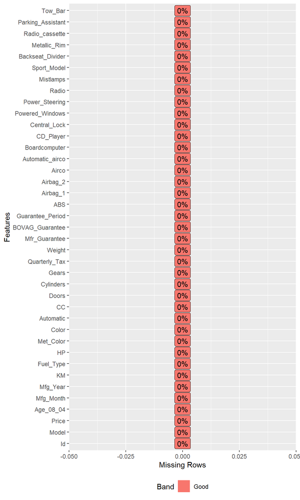

```r
plot_missing(Toyota) # Plots the percentages of missing values
```

```r
Toyota <- Toyota[,c(3:4,7:9,12,14,17,19,21,25:26,28,30,34,39)] # Keep only the 15 variables started in the Data Overview section (page 245)
head(Toyota)
```

```
##   Price Age_08_04    KM Fuel_Type HP Automatic Doors Quarterly_Tax
## 1 13500        23 46986    Diesel 90         0     3           210
## 2 13750        23 72937    Diesel 90         0     3           210
## 3 13950        24 41711    Diesel 90         0     3           210
## 4 14950        26 48000    Diesel 90         0     3           210
## 5 13750        30 38500    Diesel 90         0     3           210
## 6 12950        32 61000    Diesel 90         0     3           210
##   Mfr_Guarantee Guarantee_Period Airco Automatic_airco CD_Player
## 1             0                3     0               0         0
## 2             0                3     1               0         1
## 3             1                3     0               0         0
## 4             1                3     0               0         0
## 5             1                3     1               0         0
## 6             0                3     1               0         0
##   Powered_Windows Sport_Model Tow_Bar
## 1               1           0       0
## 2               0           0       0
## 3               0           0       0
## 4               0           0       0
## 5               1           0       0
## 6               1           0       0
```

```r
# Create a summary statistics table to show metrics, ensuring that missing values are not included
Summary <- data.frame(mean = sapply(Toyota[,c(1:3, 5:16)], mean,na.rm = T)
                ,median = sapply(Toyota[,c(1:3, 5:16)], median,na.rm = T)
                ,min = sapply(Toyota[,c(1:3, 5:16)], min,na.rm = T)
                ,max = sapply(Toyota[,c(1:3, 5:16)], max,na.rm = T)
                ,sd = sapply(Toyota[,c(1:3, 5:16)], sd,na.rm = T))
colnames(Summary) = c("Mean","Median","Min","Max","Standard Deviation")
Summary
```

```
##                            Mean  Median  Min    Max Standard Deviation
## Price            10730.82451253  9900.0 4350  32500       3626.9645849
## Age_08_04           55.94707521    61.0    1     80         18.5999883
## KM               68533.25974930 63389.5    1 243000      37506.4488722
## HP                 101.50208914   110.0   69    192         14.9810797
## Automatic            0.05571031     0.0    0      1          0.2294413
## Doors                4.03342618     4.0    2      5          0.9526766
## Quarterly_Tax       87.12256267    85.0   19    283         41.1286113
## Mfr_Guarantee        0.40947075     0.0    0      1          0.4919075
## Guarantee_Period     3.81545961     3.0    3     36          3.0110247
## Airco                0.50835655     1.0    0      1          0.5001043
## Automatic_airco      0.05640669     0.0    0      1          0.2307857
## CD_Player            0.21866295     0.0    0      1          0.4134834
## Powered_Windows      0.56197772     1.0    0      1          0.4963167
## Sport_Model          0.30013928     0.0    0      1          0.4584780
## Tow_Bar              0.27785515     0.0    0      1          0.4480976
```

```r
# Convert categorical Fuel_Type to dummy variable
Toyota$Fuel_Type = as.factor(Toyota$Fuel_Type) # Treat Fuel_Type as categorical (R will create dummy variables) (page 245)

dummy <- dummyVars(~.,data = Toyota) # Creates a full set of dummy variables for specified factors

Toyota_Data <- as.data.frame(predict(dummy, newdata = Toyota)) # Creates new dataset with the dummy variables

str(Toyota_Data) # Used for compactly displaying the internal structure of a R object
```

```
## 'data.frame':    1436 obs. of  18 variables:
##  $ Price           : num  13500 13750 13950 14950 13750 ...
##  $ Age_08_04       : num  23 23 24 26 30 32 27 30 27 23 ...
##  $ KM              : num  46986 72937 41711 48000 38500 ...
##  $ Fuel_Type.CNG   : num  0 0 0 0 0 0 0 0 0 0 ...
##  $ Fuel_Type.Diesel: num  1 1 1 1 1 1 1 1 0 1 ...
##  $ Fuel_Type.Petrol: num  0 0 0 0 0 0 0 0 1 0 ...
##  $ HP              : num  90 90 90 90 90 90 90 90 192 69 ...
##  $ Automatic       : num  0 0 0 0 0 0 0 0 0 0 ...
##  $ Doors           : num  3 3 3 3 3 3 3 3 3 3 ...
##  $ Quarterly_Tax   : num  210 210 210 210 210 210 210 210 100 185 ...
##  $ Mfr_Guarantee   : num  0 0 1 1 1 0 0 1 0 0 ...
##  $ Guarantee_Period: num  3 3 3 3 3 3 3 3 3 3 ...
##  $ Airco           : num  0 1 0 0 1 1 1 1 1 1 ...
##  $ Automatic_airco : num  0 0 0 0 0 0 0 0 0 0 ...
##  $ CD_Player       : num  0 1 0 0 0 0 0 1 0 0 ...
##  $ Powered_Windows : num  1 0 0 0 1 1 1 1 1 0 ...
##  $ Sport_Model     : num  0 0 0 0 0 0 1 0 0 0 ...
##  $ Tow_Bar         : num  0 0 0 0 0 0 0 0 0 0 ...
```

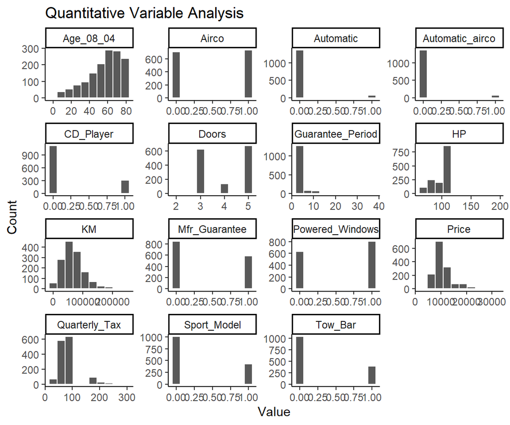

```r
Toyota_data <- Toyota[,c(1:3,5:16)] # Excluding Fuel_Type for quantitative analysis

ggplot(gather(data = Toyota_data),aes(value)) +
  geom_histogram(bins = 10, color = "white") + # Creates bin sizing and sets the lines as white
  facet_wrap(~key,scales = "free") + # Converting the graphs into panels
  ggtitle("Quantitative Variable Analysis") + # Title name
  ylab("Count") + xlab("Value") + # Label names
  theme_classic() # A classic theme, with x and y axis lines and no grid lines
```

For all three exercises, they utilize the ToyotaCorolla.csv that contains data on used cars within the Netherlands. In that summer of 2004, we can see that there are 1,436 observations and 39 variables pertaining to an individual used car. In the exploratory review, I will analyze different statistical measures as well as gather an overall understanding of how our explanatory variables could impact our response (price). If the reader needs a refresher of the exploratory analysis either in 9.3 or 11.3, please refer to the summary below.

Before moving forward, we need to check missing values. Fortunately for this analysis, there are no N/A data points. Since there are 15 attributes that we will focus on for the regression, we only keep those moving forward in our Toyota dataset.

Within those 15 quantitative variables, the mean, median, min, max, and standard deviation all differ. Price will range from $4,350 to $32,500, and we will need to check which variables are most important. For the variables that are binary, those will range between 0 and 1. Hence, their standard deviation and mean being between those two values.

```r
# Partition data (page 159)
set.seed(1) #  Set seed for reproducing the partition into 50%, 30%, and 20%. (page 159)
# Partition data for the training set - 50%
train.index <- sample(rownames(Toyota), 0.5*dim(Toyota)[1])
train.df <- Toyota[train.index, ]

# Partition data for the validation set - 30%
valid.index <- sample(setdiff(rownames(Toyota),train.index), 0.3*dim(Toyota)[1])
valid.df <- Toyota[valid.index, ]

# Partition data for the test set - 20%
test.index = setdiff(rownames(Toyota), union(train.index, valid.index))
test.df <- Toyota[test.index, ]
```

```r
# Initialize normalized training, validation data, complete data frames to originals (page 177)
train.norm.df = train.df
valid.norm.df = valid.df
test.norm.df = test.df

selected.var <- c(1,2,3,5,7,8,10) # Select variables for regression (page 159)

# Use preProcess() from the caret package for the quantitative variables
norm.values = preProcess(train.df[, selected.var], method=c("center", "scale"))

train.norm.df[, selected.var] = predict(norm.values, train.df[, selected.var]) # Select the quantitative values for prediction for training

valid.norm.df[, selected.var] = predict(norm.values, valid.df[, selected.var]) # Select the quantitative values for prediction for valid

test.norm.df[, selected.var] = predict(norm.values, test.df[, selected.var]) # Select the quantitative values for prediction for test

car.lm <- lm(Price ~ ., data = train.norm.df) #  Create regression. Use . after ~ to include all the remaining columns in train.norm.df as predictors (page 159)

# Use options() to ensure numbers are not displayed in scientific notation (page 159)
options(scipen = 999)
summary(car.lm)
```

```
##
## Call:
## lm(formula = Price ~ ., data = train.norm.df)
##
## Residuals:
##      Min       1Q   Median       3Q      Max
## -1.39545 -0.20242 -0.01468  0.17840  1.91530
##
## Coefficients:
##                  Estimate Std. Error t value             Pr(>|t|)
## (Intercept)      -0.60794    0.14321  -4.245         0.0000247949 ***
## Age_08_04        -0.54127    0.02054 -26.346 < 0.0000000000000002 ***
## KM               -0.18515    0.01849 -10.013 < 0.0000000000000002 ***
## Fuel_TypeDiesel   0.58458    0.14183   4.122         0.0000421240 ***
## Fuel_TypePetrol   0.36226    0.14798   2.448             0.014606 *
## HP                0.15210    0.01735   8.764 < 0.0000000000000002 ***
## Automatic         0.12320    0.06197   1.988             0.047201 *
## Doors             0.04943    0.01350   3.662             0.000269 ***
## Quarterly_Tax     0.14677    0.02705   5.426         0.0000000796 ***
## Mfr_Guarantee     0.06685    0.02732   2.447             0.014642 *
## Guarantee_Period  0.05534    0.01353   4.089         0.0000483113 ***
## Airco             0.05159    0.03272   1.577             0.115349
## Automatic_airco   0.85687    0.06378  13.434 < 0.0000000000000002 ***
## CD_Player         0.12772    0.03561   3.586             0.000359 ***
## Powered_Windows   0.10659    0.03177   3.355             0.000838 ***
## Sport_Model       0.14201    0.02953   4.809         0.0000018536 ***
## Tow_Bar          -0.06591    0.03043  -2.166             0.030657 *
## ---
## Signif. codes:  0 '***' 0.001 '**' 0.01 '*' 0.05 '.' 0.1 ' ' 1
##
## Residual standard error: 0.3394 on 701 degrees of freedom
## Multiple R-squared:  0.8874, Adjusted R-squared:  0.8848
## F-statistic: 345.2 on 16 and 701 DF,  p-value: < 0.00000000000000022
```

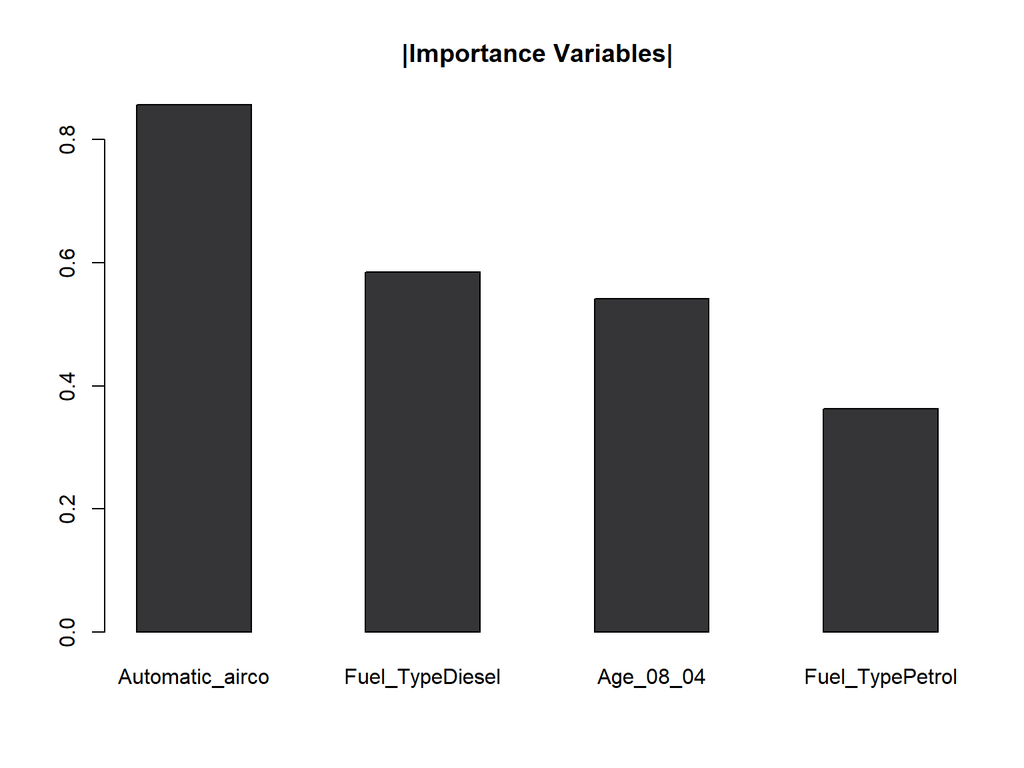

```r
# Create matrix for stacked bar chart
data <- as.matrix(data.frame("Automatic_airco" = c(0.85687),
                             "Fuel_TypeDiesel" = c(0.58458),
                             "Age_08_04" = c(0.54127),
                             "Fuel_TypePetrol" = c(0.36226)))
rownames(data) <- c("Variable Importance")

# Create grouped barchart
barplot(data,
        col = c("#353436"),
        beside = TRUE, main = "|Importance Variables|")
```

First, we fit a multiple linear regression model between the explanatory and response variables. Since the main goal is to predict price for Toyota’s used cars, we want to run over analysis over our training set which is 50% of this dataset. There is one categorical variable, ‘Fuel_Type,’ that we must convert into a dummy variable. Since there is redundant information for two of the three dummy variables. R’s ‘lm’ routine will automatically handle this issue. Therefore, this is why we only see Petrol and Diesel, and not CNG (page 157). Other important points to mention is that the Adjusted R-squared is 88.48. This insinuates that about 90% of the variance of the dependent variables being studied are explained by the variance of the independent variable. F-stat is significant, and therefore, we reject the null hypothesis since α = 0.05. A model is qualitatively good if the Fisher test is significant and the R-squared is big. Additionally, ‘airco’ is not statistically significant as its p-vale is above alpha = 0.5. There is not enough evidence, and therefore, we fail to reject the null hypothesis (H0: β0 = 0). But, there are car specifications that are influential due to their highest standardized coefficients. These appear to be the following:

| Variable | Coefficient |
| --- | --- |
| Automatic_airco | 0.85687 |
| Fuel_TypeDiesel | 0.58458 |
| Age_08_04 | -0.54127 |
| Fuel_TypePetrol | 0.36226 |

Please notice that the bar chart above shows the same values but in absolute terms. Also, we know that our coefficients play a roll in picking the most important variables, but those that have an alpha less than 0.05, would mean that they could be potentially added to the model.

```r
# Use predict() to make predictions on a new set (page 160)
car.lm.pred <- predict(car.lm, valid.norm.df)

options(scipen=999) # Use options() to ensure numbers are not displayed in scientific notation (page 159)

# Calculate residuals based off linear regression and valid norm set
some.residuals <- valid.norm.df$Price[1:10] - car.lm.pred[1:10]

# Create dataset that is seen below within a table format
data.frame("Predicted" = car.lm.pred[1:10], "Actual" = valid.norm.df$Price[1:10], "Residual" = some.residuals)
```

```
##        Predicted      Actual     Residual
## 274   0.68768444  0.68588889 -0.001795545
## 965  -0.28605053  0.01244318  0.298493703
## 477   0.06777714 -0.17612162 -0.243898764
## 558  -0.12098797  0.76670238  0.887690344
## 942  -0.18917859 -0.44549991 -0.256321317
## 47    1.58978348  1.89809118  0.308307695
## 1061 -1.32397875 -0.79569168  0.528287070
## 639  -0.50935008 -0.12224597  0.387104110
## 1223 -0.69083317 -0.71487820 -0.024045027
## 272   0.52099257  0.55119975  0.030207180
```

```r
options(scipen=999, digits = 3) # Use options() to ensure numbers are not displayed in scientific notation (page 159)

# Use accuracy() to compute common accuracy measures (page 160)
accuracy(car.lm.pred, valid.norm.df$Price)
```

```
##               ME  RMSE   MAE   MPE MAPE
## Test set 0.00915 0.338 0.261 -77.2  200
```

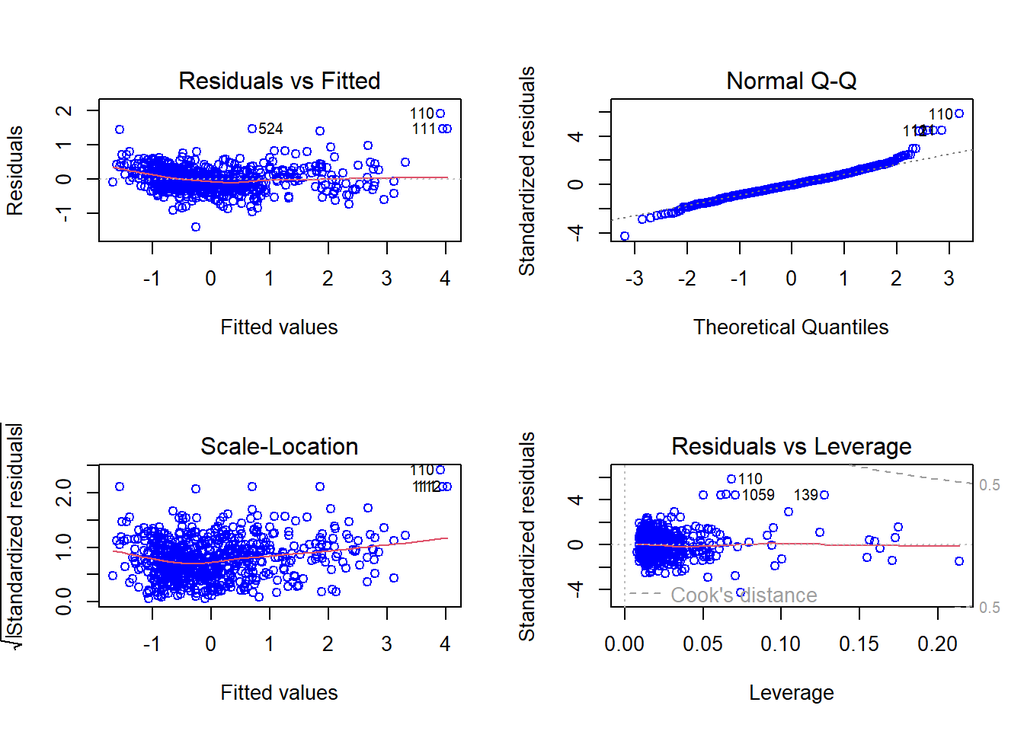

```r
par(mfrow = c(2,2)) # Organizes graphs in a specific order
plot(car.lm, col = "blue") # Plots the linear regression
```

With any model, the residuals should assume the following:  
1. There should be a similar variability about the X-axis at all points, around 0 on the Y -axis  
2. Check the relationship or patterns  
3. Check the normality of the errors  
To ensure this criteria is met, we use the Residuals vs Fitted to check the lack of structure or presence of extreme values. It is important to note the following:  
- A residual will be considered large if its absolute value exceeds (approximately) 2σ(hat)  
- When n is large, a residual will be considered large if its absolute value exceeds (approximately) 4σ(hat) (otherwise, too many residues will be considered large!)

All values are weighted evenly in a regression model, including potential outliers. As mentioned above, we need to ensure that the residuals are within our limits. Referring back to the summary(car.lm) output, the model’s residual standard error is 0.3394. If we multiple by ±2, we return our estimate. In this case, let us focus on the upper limit of 0.6788. Visually, we can determine that the points ‘110’, ‘524’, and ‘111’ fall outside that of 0.6788 and would be considered large. There could also be additional outliers that are not labeled too. The residuals seem to be concentrated towards the left side of the graph, even though they are distributed around zero.

To check the normality of the errors (εi) we do a normal Q-Q plot of the residuals. For this graph, we can use the “thickness of a pencil approach.” If we were to put the pencil on the regression line, it is immediately noticed that those same three points that are mentioned as outliers above, fall outside of that pencil. If we do not consider those extreme values, the Q-Q plot seems to be normally distributed minus the departures on both of the tail parts.

Below shows the frequency at which the validation set has model errors. The residuals are primarily between ±0.5. In addition, the histogram is roughly bell-shaped so it is an indication that it is reasonable to assume that the errors have a normal distribution.

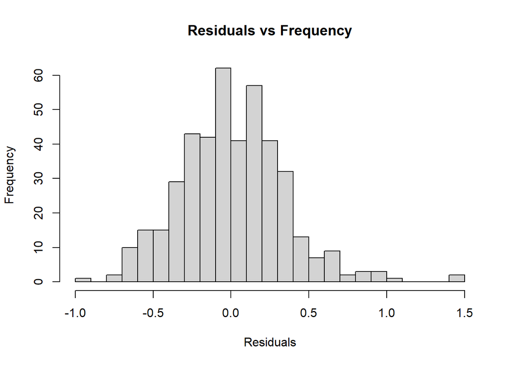

```r
# Plotting histogram of validation errors (page 161)
all.residuals <- valid.norm.df$Price - car.lm.pred

hist(all.residuals, breaks = 20, xlab = "Residuals", main = "Residuals vs Frequency") # Creates histogram of residual frequencies
```

The next analysis will discuss the exhaustive method for reducing predictors.

```r
# Use regsubsets() in package leaps to run an exhaustive search.
# Unlike with lm, categorical predictors must be turned into dummies manually.

# Create dummies for fuel type
Fuel_Type <- as.data.frame(model.matrix(~ 0 + Fuel_Type, data=train.df))

# Replace Fuel_Type column with 2 dummies
train.df <- cbind(train.df[,-4], Fuel_Type[,])
head(train.df)
```

```
##      Price Age_08_04     KM  HP Automatic Doors Quarterly_Tax Mfr_Guarantee
## 1017  9250        65  35283  86         0     3            69             0
## 679   9895        68 102494 110         0     5            85             1
## 129  17950        17  33740  97         0     5            85             0
## 930   9995        57  55844  86         0     5            69             0
## 471  10900        50  65471  97         0     5            85             0
## 299  13995        35  41000 110         0     5            85             1
##      Guarantee_Period Airco Automatic_airco CD_Player Powered_Windows
## 1017                3     0               0         0               1
## 679                 3     1               0         0               1
## 129                 3     1               1         0               1
## 930                 3     1               0         0               1
## 471                 3     1               0         1               0
## 299                 3     1               0         1               1
##      Sport_Model Tow_Bar Fuel_TypeCNG Fuel_TypeDiesel Fuel_TypePetrol
## 1017           0       0            0               0               1
## 679            0       1            0               0               1
## 129            1       0            0               0               1
## 930            0       1            0               0               1
## 471            0       0            0               0               1
## 299            0       0            0               0               1
```

```r
# Use regsubsets to get the response versus explanatory variables to calculate the various metrics below
search <- regsubsets(Price ~ ., data = train.df, nbest = 1, nvmax = dim(train.df)[2], method = "exhaustive")

sum <- summary(search)

# show models
sum$which
```

```
##    (Intercept) Age_08_04    KM    HP Automatic Doors Quarterly_Tax
## 1         TRUE      TRUE FALSE FALSE     FALSE FALSE         FALSE
## 2         TRUE      TRUE FALSE FALSE     FALSE FALSE         FALSE
## 3         TRUE      TRUE FALSE  TRUE     FALSE FALSE         FALSE
## 4         TRUE      TRUE FALSE  TRUE     FALSE FALSE          TRUE
## 5         TRUE      TRUE  TRUE  TRUE     FALSE FALSE          TRUE
## 6         TRUE      TRUE  TRUE  TRUE     FALSE FALSE          TRUE
## 7         TRUE      TRUE  TRUE  TRUE     FALSE FALSE          TRUE
## 8         TRUE      TRUE  TRUE  TRUE     FALSE FALSE          TRUE
## 9         TRUE      TRUE  TRUE  TRUE     FALSE FALSE          TRUE
## 10        TRUE      TRUE  TRUE  TRUE     FALSE FALSE          TRUE
## 11        TRUE      TRUE  TRUE  TRUE     FALSE  TRUE          TRUE
## 12        TRUE      TRUE  TRUE  TRUE     FALSE  TRUE          TRUE
## 13        TRUE      TRUE  TRUE  TRUE     FALSE  TRUE          TRUE
## 14        TRUE      TRUE  TRUE  TRUE     FALSE  TRUE          TRUE
```

[output cut: 53 more lines]

```r
# show metrics
sum$rsq
```

```
##  [1] 0.758 0.821 0.838 0.851 0.869 0.873 0.875 0.878 0.880 0.882 0.884 0.885
## [13] 0.886 0.886 0.887 0.887
```

```r
sum$adjr2
```

```
##  [1] 0.758 0.820 0.837 0.850 0.868 0.872 0.874 0.876 0.879 0.881 0.882 0.883
## [13] 0.884 0.884 0.885 0.885
```

```r
sum$cp
```

```
##  [1] 790.9 403.2 297.4 216.8 110.6  88.0  72.1  60.3  47.0  35.9  27.9  23.9
## [13]  20.7  18.8  16.5  16.0
```

With the exhaustive search, there are two components that will help the analyst determine which predictors should be used in the model. The first is the R-squared adjusted that accounts for the predictors used. Since you want the model to have the highest R-squared prior to it plateauing, the best model appears to be the one labeled 15. That means that it includes all variables but Airco which is seen as not statistically significant. The second criterion is the Mallow’s Cp. This assumes that the full model is unbiased and we can show that be examining if the Cp is near p + 1. The Cp shows that using all of the predictors is good since 16.0 is the smallest value.

Here, we code for the stepwise regression using the backwards method to reduce predictors. These next three analyses are considered the iterative approach.

```r
# Use step() to run stepwise regression (page 167)
# Set directions = to either "backward", "forward", or "both".
car.lm.step.back <- step(car.lm, direction = "backward")
```

```
## Start:  AIC=-1535
## Price ~ Age_08_04 + KM + Fuel_Type + HP + Automatic + Doors +
##     Quarterly_Tax + Mfr_Guarantee + Guarantee_Period + Airco +
##     Automatic_airco + CD_Player + Powered_Windows + Sport_Model +
##     Tow_Bar
##
##                    Df Sum of Sq   RSS   AIC
## <none>                           80.7 -1535
## - Airco             1       0.3  81.0 -1534
## - Automatic         1       0.5  81.2 -1533
## - Tow_Bar           1       0.5  81.3 -1532
## - Mfr_Guarantee     1       0.7  81.4 -1531
## - Powered_Windows   1       1.3  82.0 -1526
## - CD_Player         1       1.5  82.2 -1524
## - Doors             1       1.5  82.3 -1523
## - Fuel_Type         2       2.1  82.8 -1521
## - Guarantee_Period  1       1.9  82.7 -1520
## - Sport_Model       1       2.7  83.4 -1514
## - Quarterly_Tax     1       3.4  84.1 -1507
## - HP                1       8.8  89.6 -1462
## - KM                1      11.5  92.3 -1441
## - Automatic_airco   1      20.8 101.5 -1372
## - Age_08_04         1      80.0 160.7 -1043
```

```r
summary(car.lm.step.back)
```

```
##
## Call:
## lm(formula = Price ~ Age_08_04 + KM + Fuel_Type + HP + Automatic +
##     Doors + Quarterly_Tax + Mfr_Guarantee + Guarantee_Period +
##     Airco + Automatic_airco + CD_Player + Powered_Windows + Sport_Model +
##     Tow_Bar, data = train.norm.df)
##
## Residuals:
##     Min      1Q  Median      3Q     Max
## -1.3954 -0.2024 -0.0147  0.1784  1.9153
##
## Coefficients:
##                  Estimate Std. Error t value             Pr(>|t|)
## (Intercept)       -0.6079     0.1432   -4.25           0.00002479 ***
## Age_08_04         -0.5413     0.0205  -26.35 < 0.0000000000000002 ***
## KM                -0.1852     0.0185  -10.01 < 0.0000000000000002 ***
## Fuel_TypeDiesel    0.5846     0.1418    4.12           0.00004212 ***
## Fuel_TypePetrol    0.3623     0.1480    2.45              0.01461 *
## HP                 0.1521     0.0174    8.76 < 0.0000000000000002 ***
## Automatic          0.1232     0.0620    1.99              0.04720 *
## Doors              0.0494     0.0135    3.66              0.00027 ***
## Quarterly_Tax      0.1468     0.0271    5.43           0.00000008 ***
## Mfr_Guarantee      0.0669     0.0273    2.45              0.01464 *
## Guarantee_Period   0.0553     0.0135    4.09           0.00004831 ***
## Airco              0.0516     0.0327    1.58              0.11535
## Automatic_airco    0.8569     0.0638   13.43 < 0.0000000000000002 ***
## CD_Player          0.1277     0.0356    3.59              0.00036 ***
## Powered_Windows    0.1066     0.0318    3.35              0.00084 ***
## Sport_Model        0.1420     0.0295    4.81           0.00000185 ***
## Tow_Bar           -0.0659     0.0304   -2.17              0.03066 *
## ---
## Signif. codes:  0 '***' 0.001 '**' 0.01 '*' 0.05 '.' 0.1 ' ' 1
##
## Residual standard error: 0.339 on 701 degrees of freedom
## Multiple R-squared:  0.887,  Adjusted R-squared:  0.885
## F-statistic:  345 on 16 and 701 DF,  p-value: <0.0000000000000002
```

```r
car.lm.step.pred.back <- predict(car.lm.step.back, valid.norm.df) # Used to predict the values based on the input data
accuracy(car.lm.step.pred.back, valid.norm.df$Price) # Number of correct predictions created
```

```
##               ME  RMSE   MAE   MPE MAPE
## Test set 0.00915 0.338 0.261 -77.2  200
```

For the backwards stepwise, we start with all predictors and then at each step, eliminate the least useful predictor. We will consider what the exhaustive method mentioned in the book by utilizing the Akaike Information Criterion (AIC) which ‘measures the goodness of fit of a model, but also includes a penalty that is a function of the number of parameters in the model’ (page 163). Again, we notice that Airco is not significant as it has a p-value larger than 0.05. The top most important variables are Age_08_04, Automatic_airco, KM and, HP as their AIC’s are as it has the lowest AIC which offers the best fit.

This time, we will go in the opposite direction and show how the forward selection will reduce the car predictors.

```r
# Use step() to run stepwise regression (page 167) and from the Errata
# Set directions = to either "backward", "forward", or "both".
# create model with no predictors
car.lm.null <- lm(Price~1, data = train.norm.df)

# use step() to run forward regression.
car.lm.step <- step(car.lm.null, scope=list(lower=car.lm.null, upper=car.lm), direction = "forward")
```

```
## Start:  AIC=1
## Price ~ 1
##
##                    Df Sum of Sq RSS   AIC
## + Age_08_04         1       543 174 -1015
## + Automatic_airco   1       243 474  -294
## + KM                1       235 482  -283
## + CD_Player         1       176 541  -199
## + Airco             1       125 592  -134
## + Powered_Windows   1        87 630   -90
## + HP                1        67 650   -68
## + Quarterly_Tax     1        54 663   -53
## + Mfr_Guarantee     1        35 682   -33
## + Sport_Model       1        30 687   -27
## + Tow_Bar           1        29 688   -26
## + Doors             1        22 695   -19
## + Fuel_Type         2        11 706    -6
## + Guarantee_Period  1         5 712    -2
## + Automatic         1         2 715     1
## <none>                          717     1
##
## Step:  AIC=-1015
## Price ~ Age_08_04
##
##                    Df Sum of Sq RSS   AIC
## + Automatic_airco   1      44.9 129 -1229
## + HP                1      23.6 150 -1118
## + KM                1      12.5 161 -1067
## + Powered_Windows   1       8.3 165 -1049
## + Airco             1       5.6 168 -1037
## + Sport_Model       1       5.6 168 -1037
## + Quarterly_Tax     1       3.7 170 -1029
## + CD_Player         1       2.6 171 -1024
## + Mfr_Guarantee     1       2.6 171 -1024
## + Automatic         1       2.3 171 -1023
## + Doors             1       2.0 172 -1022
## + Fuel_Type         2       1.7 172 -1018
## <none>                          174 -1015
## + Guarantee_Period  1       0.2 173 -1014
## + Tow_Bar           1       0.1 174 -1014
```

[output cut: 174 more lines]

```
##
## Step:  AIC=-1534
## Price ~ Age_08_04 + Automatic_airco + HP + Quarterly_Tax + KM +
##     Powered_Windows + Fuel_Type + Sport_Model + Guarantee_Period +
##     CD_Player + Doors + Mfr_Guarantee + Tow_Bar + Automatic
##
##         Df Sum of Sq  RSS   AIC
## + Airco  1     0.286 80.7 -1535
## <none>               81.0 -1534
##
## Step:  AIC=-1535
## Price ~ Age_08_04 + Automatic_airco + HP + Quarterly_Tax + KM +
##     Powered_Windows + Fuel_Type + Sport_Model + Guarantee_Period +
##     CD_Player + Doors + Mfr_Guarantee + Tow_Bar + Automatic +
##     Airco
```

```r
summary(car.lm.step)
```

```
##
## Call:
## lm(formula = Price ~ Age_08_04 + Automatic_airco + HP + Quarterly_Tax +
##     KM + Powered_Windows + Fuel_Type + Sport_Model + Guarantee_Period +
##     CD_Player + Doors + Mfr_Guarantee + Tow_Bar + Automatic +
##     Airco, data = train.norm.df)
##
## Residuals:
##     Min      1Q  Median      3Q     Max
## -1.3954 -0.2024 -0.0147  0.1784  1.9153
##
## Coefficients:
##                  Estimate Std. Error t value             Pr(>|t|)
## (Intercept)       -0.6079     0.1432   -4.25           0.00002479 ***
## Age_08_04         -0.5413     0.0205  -26.35 < 0.0000000000000002 ***
## Automatic_airco    0.8569     0.0638   13.43 < 0.0000000000000002 ***
## HP                 0.1521     0.0174    8.76 < 0.0000000000000002 ***
## Quarterly_Tax      0.1468     0.0271    5.43           0.00000008 ***
## KM                -0.1852     0.0185  -10.01 < 0.0000000000000002 ***
## Powered_Windows    0.1066     0.0318    3.35              0.00084 ***
## Fuel_TypeDiesel    0.5846     0.1418    4.12           0.00004212 ***
## Fuel_TypePetrol    0.3623     0.1480    2.45              0.01461 *
## Sport_Model        0.1420     0.0295    4.81           0.00000185 ***
## Guarantee_Period   0.0553     0.0135    4.09           0.00004831 ***
## CD_Player          0.1277     0.0356    3.59              0.00036 ***
## Doors              0.0494     0.0135    3.66              0.00027 ***
## Mfr_Guarantee      0.0669     0.0273    2.45              0.01464 *
## Tow_Bar           -0.0659     0.0304   -2.17              0.03066 *
## Automatic          0.1232     0.0620    1.99              0.04720 *
## Airco              0.0516     0.0327    1.58              0.11535
## ---
## Signif. codes:  0 '***' 0.001 '**' 0.01 '*' 0.05 '.' 0.1 ' ' 1
##
## Residual standard error: 0.339 on 701 degrees of freedom
## Multiple R-squared:  0.887,  Adjusted R-squared:  0.885
## F-statistic:  345 on 16 and 701 DF,  p-value: <0.0000000000000002
```

```r
car.lm.step.pred <- predict(car.lm.step, valid.norm.df) # Used to predict the values based on the input data
accuracy(car.lm.step.pred, valid.norm.df$Price) # Number of correct predictions created
```

```
##               ME  RMSE   MAE   MPE MAPE
## Test set 0.00915 0.338 0.261 -77.2  200
```

The last stepwise includes the direction of ‘both’ which produces the same results as the other two iterative methods above.

```r
# Use step() to run stepwise regression (page 167)
# Set directions = to either "backward", "forward", or "both".
car.lm.step.both <- step(car.lm, direction = "both")
```

```
## Start:  AIC=-1535
## Price ~ Age_08_04 + KM + Fuel_Type + HP + Automatic + Doors +
##     Quarterly_Tax + Mfr_Guarantee + Guarantee_Period + Airco +
##     Automatic_airco + CD_Player + Powered_Windows + Sport_Model +
##     Tow_Bar
##
##                    Df Sum of Sq   RSS   AIC
## <none>                           80.7 -1535
## - Airco             1       0.3  81.0 -1534
## - Automatic         1       0.5  81.2 -1533
## - Tow_Bar           1       0.5  81.3 -1532
## - Mfr_Guarantee     1       0.7  81.4 -1531
## - Powered_Windows   1       1.3  82.0 -1526
## - CD_Player         1       1.5  82.2 -1524
## - Doors             1       1.5  82.3 -1523
## - Fuel_Type         2       2.1  82.8 -1521
## - Guarantee_Period  1       1.9  82.7 -1520
## - Sport_Model       1       2.7  83.4 -1514
## - Quarterly_Tax     1       3.4  84.1 -1507
## - HP                1       8.8  89.6 -1462
## - KM                1      11.5  92.3 -1441
## - Automatic_airco   1      20.8 101.5 -1372
## - Age_08_04         1      80.0 160.7 -1043
```

```r
summary(car.lm.step.both)
```

```
##
## Call:
## lm(formula = Price ~ Age_08_04 + KM + Fuel_Type + HP + Automatic +
##     Doors + Quarterly_Tax + Mfr_Guarantee + Guarantee_Period +
##     Airco + Automatic_airco + CD_Player + Powered_Windows + Sport_Model +
##     Tow_Bar, data = train.norm.df)
##
## Residuals:
##     Min      1Q  Median      3Q     Max
## -1.3954 -0.2024 -0.0147  0.1784  1.9153
##
## Coefficients:
##                  Estimate Std. Error t value             Pr(>|t|)
## (Intercept)       -0.6079     0.1432   -4.25           0.00002479 ***
## Age_08_04         -0.5413     0.0205  -26.35 < 0.0000000000000002 ***
## KM                -0.1852     0.0185  -10.01 < 0.0000000000000002 ***
## Fuel_TypeDiesel    0.5846     0.1418    4.12           0.00004212 ***
## Fuel_TypePetrol    0.3623     0.1480    2.45              0.01461 *
## HP                 0.1521     0.0174    8.76 < 0.0000000000000002 ***
## Automatic          0.1232     0.0620    1.99              0.04720 *
## Doors              0.0494     0.0135    3.66              0.00027 ***
## Quarterly_Tax      0.1468     0.0271    5.43           0.00000008 ***
## Mfr_Guarantee      0.0669     0.0273    2.45              0.01464 *
## Guarantee_Period   0.0553     0.0135    4.09           0.00004831 ***
## Airco              0.0516     0.0327    1.58              0.11535
## Automatic_airco    0.8569     0.0638   13.43 < 0.0000000000000002 ***
## CD_Player          0.1277     0.0356    3.59              0.00036 ***
## Powered_Windows    0.1066     0.0318    3.35              0.00084 ***
## Sport_Model        0.1420     0.0295    4.81           0.00000185 ***
## Tow_Bar           -0.0659     0.0304   -2.17              0.03066 *
## ---
## Signif. codes:  0 '***' 0.001 '**' 0.01 '*' 0.05 '.' 0.1 ' ' 1
##
## Residual standard error: 0.339 on 701 degrees of freedom
## Multiple R-squared:  0.887,  Adjusted R-squared:  0.885
## F-statistic:  345 on 16 and 701 DF,  p-value: <0.0000000000000002
```

```r
car.lm.step.pred.both <- predict(car.lm.step.both, valid.norm.df)
# Used to predict the values based on the input data
accuracy(car.lm.step.pred.both, valid.norm.df$Price) # Number of correct predictions created
```

```
##               ME  RMSE   MAE   MPE MAPE
## Test set 0.00915 0.338 0.261 -77.2  200
```